# INN_Learner_Notebook_Full_code

### Neural Network with Balanced Data (by applying SMOTE) and SGD Optimizer

```python
#apply SMOTE
sm  = SMOTE(random_state=42)
x_train_smote, y_train_smote= sm.fit_resample(x_train,y_train)
print('After UpSampling, the shape of train_X: {}'.format(x_train_smote.shape))
print('After UpSampling, the shape of train_y: {} \n'.format(y_train_smote.shape))
```

```
After UpSampling, the shape of train_X: (10192, 11)
After UpSampling, the shape of train_y: (10192,)
```

```python
tf.keras.backend.clear_session()
#Fixing the seed for random number generators so that we can ensure we receive the same output everytime
np.random.seed(2)
random.seed(2)
tf.random.set_seed(2)
```

```python
#Initializing the neural network
model3 = Sequential()
model3.add(Dense(64,activation="relu",input_dim=x_train_smote.shape[1]))
model3.add(Dense(32,activation="relu"))
model3.add(Dense(16,activation="relu"))
model3.add(Dense(1,activation="sigmoid"))
```

```python
# define SGD optimizer and binary cross entropy loss
optimizer = tf.keras.optimizers.SGD()
metric = keras.metrics.Recall()
model3.compile(loss='binary_crossentropy', optimizer=optimizer,metrics=[metric])
```

```python
model3.summary()
```

```
Model: "sequential"
_________________________________________________________________
 Layer (type)                Output Shape              Param #
=================================================================
 dense (Dense)               (None, 64)                768

 dense_1 (Dense)             (None, 32)                2080

 dense_2 (Dense)             (None, 16)                528

 dense_3 (Dense)             (None, 1)                 17

=================================================================
Total params: 3393 (13.25 KB)
Trainable params: 3393 (13.25 KB)
Non-trainable params: 0 (0.00 Byte)
_________________________________________________________________
```

```python
epochs = 30
batch_size = 32
```

```python
start = time.time()
history3 = model3.fit(x_train_smote, y_train_smote, validation_data=(x_val,y_val) , batch_size=batch_size, epochs=epochs,verbose =1)
end=time.time()
```

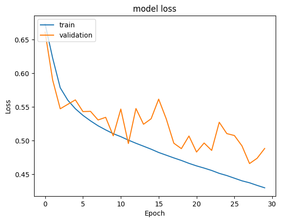

```python
#Plotting Train Loss vs Validation Loss
plt.plot(history3.history['loss'])
plt.plot(history3.history['val_loss'])
plt.title('model loss')
plt.ylabel('Loss')
plt.xlabel('Epoch')
plt.legend(['train', 'validation'], loc='upper left')
plt.show()
```

```python
model3_train_perf = model_performance_classification(model3, x_train_smote, y_train_smote)
model3_train_perf
```

|  | Accuracy | Recall | Precision | F1 Score |
| --- | --- | --- | --- | --- |
| 0 | 0.808 | 0.817 | 0.802 | 0.809 |

```python
model3_valid_perf = model_performance_classification(model3, x_val, y_val)
model3_valid_perf
```

|  | Accuracy | Recall | Precision | F1 Score |
| --- | --- | --- | --- | --- |
| 0 | 0.762 | 0.706 | 0.447 | 0.547 |

```python
#Predicting the results using best as a threshold
y_train_pred = model3.predict(x_train_smote)
y_train_pred = (y_train_pred > 0.5)
#Predicting the results using best as a threshold
y_val_pred = model3.predict(x_val)
y_val_pred = (y_val_pred > 0.5)
```

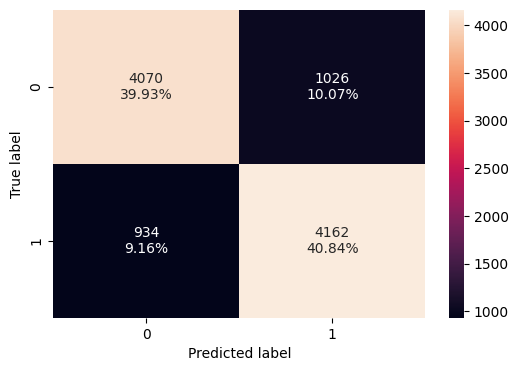

```python
#training set confusion matrix
make_confusion_matrix(y_train_smote, y_train_pred)
```

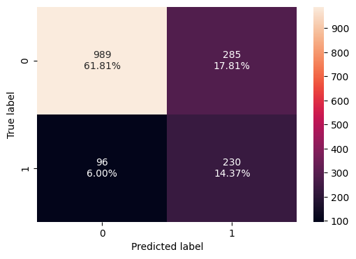

```python
#validation set confusion matrix
make_confusion_matrix(y_val, y_val_pred)
```

### Neural Network with Balanced Data (by applying SMOTE) and Adam Optimizer

```python
tf.keras.backend.clear_session()
#Fixing the seed for random number generators so that we can ensure we receive the same output everytime
np.random.seed(2)
random.seed(2)
tf.random.set_seed(2)
```

```python
#Initializing the neural network
model4 = Sequential()
model4.add(Dense(32,activation="relu",input_dim=x_train_smote.shape[1]))
model4.add(Dense(16,activation="relu"))
model4.add(Dense(8,activation="relu"))
model4.add(Dense(1,activation="sigmoid"))
```

```python
#define Adam optimizer
optimizer = tf.keras.optimizers.Adam()
metric = keras.metrics.Recall()
model4.compile(loss='binary_crossentropy', optimizer=optimizer,metrics=[metric])
```

```python
model4.summary()
```

```
Model: "sequential"
_________________________________________________________________
 Layer (type)                Output Shape              Param #
=================================================================
 dense (Dense)               (None, 32)                384

 dense_1 (Dense)             (None, 16)                528

 dense_2 (Dense)             (None, 8)                 136

 dense_3 (Dense)             (None, 1)                 9

=================================================================
Total params: 1057 (4.13 KB)
Trainable params: 1057 (4.13 KB)
Non-trainable params: 0 (0.00 Byte)
_________________________________________________________________
```

```python
epochs = 30
batch_size = 32
start = time.time()
history4 = model4.fit(x_train_smote, y_train_smote, validation_data=(x_val,y_val) , batch_size=batch_size, epochs=epochs,verbose =1)
end=time.time()
```

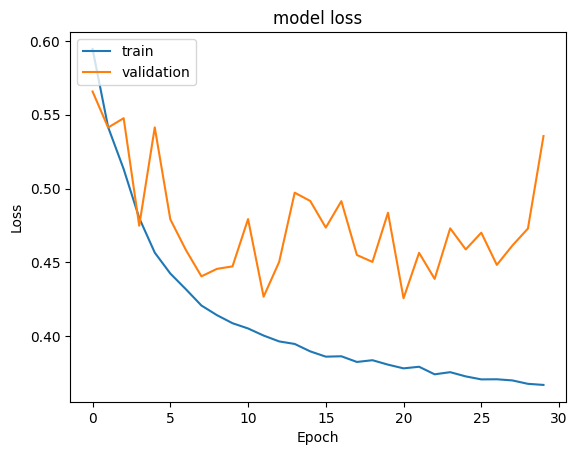

```python
#Plotting Train Loss vs Validation Loss
plt.plot(history4.history['loss'])
plt.plot(history4.history['val_loss'])
plt.title('model loss')
plt.ylabel('Loss')
plt.xlabel('Epoch')
plt.legend(['train', 'validation'], loc='upper left')
plt.show()
```

```python
#get training set performance
model4_train_perf = model_performance_classification(model4, x_train_smote, y_train_smote)
model4_train_perf
```

|  | Accuracy | Recall | Precision | F1 Score |
| --- | --- | --- | --- | --- |
| 0 | 0.835 | 0.896 | 0.798 | 0.844 |

```python
#get vlidation set performance
model4_valid_perf = model_performance_classification(model4, x_val, y_val)
model4_valid_perf
```

|  | Accuracy | Recall | Precision | F1 Score |
| --- | --- | --- | --- | --- |
| 0 | 0.758 | 0.748 | 0.444 | 0.558 |

```python
#Predicting the results using best as a threshold
y_train_pred = model4.predict(x_train_smote)
y_train_pred = (y_train_pred > 0.5)
#Predicting the results using best as a threshold
y_val_pred = model4.predict(x_val)
y_val_pred = (y_val_pred > 0.5)
```

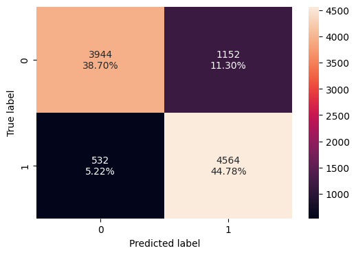

```python
#confusion matrix for training set
make_confusion_matrix(y_train_smote, y_train_pred)
```

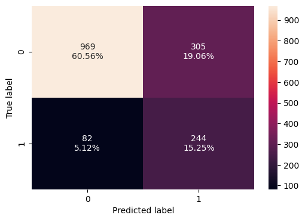

```python
#confusion matrix for validation set
make_confusion_matrix(y_val, y_val_pred)
```

### Neural Network with Balanced Data (by applying SMOTE), Adam Optimizer, and Dropout

```python
#clear session before initializing
tf.keras.backend.clear_session()
#Fixing the seed for random number generators so that we can ensure we receive the same output everytime
np.random.seed(2)
random.seed(2)
tf.random.set_seed(2)
```

```python
#Initializing the neural network with input/output, hidden and dropout layers
model5 = Sequential()
model5.add(Dense(32,activation="relu",input_dim=x_train_smote.shape[1]))
model5.add(Dropout(0.4))
model5.add(Dense(16,activation="relu"))
model5.add(Dense(8,activation="relu"))
model5.add(Dropout(0.2))
model5.add(Dense(4,activation="relu"))
model5.add(Dense(1,activation="sigmoid"))
```

```python
# defining Adam as the optimizer to be used
optimizer = tf.keras.optimizers.Adam()
metric = keras.metrics.Recall()
model5.compile(loss='binary_crossentropy', optimizer=optimizer,metrics=[metric])
```

```python
model5.summary()
```

```
Model: "sequential"
_________________________________________________________________
 Layer (type)                Output Shape              Param #
=================================================================
 dense (Dense)               (None, 32)                384

 dropout (Dropout)           (None, 32)                0

 dense_1 (Dense)             (None, 16)                528

 dense_2 (Dense)             (None, 8)                 136

 dropout_1 (Dropout)         (None, 8)                 0

 dense_3 (Dense)             (None, 4)                 36

 dense_4 (Dense)             (None, 1)                 5

=================================================================
Total params: 1089 (4.25 KB)
Trainable params: 1089 (4.25 KB)
Non-trainable params: 0 (0.00 Byte)
_________________________________________________________________
```

```python
epochs = 30
batch_size = 32

start = time.time()
history5 = model5.fit(x_train_smote, y_train_smote, validation_data=(x_val,y_val) , batch_size=batch_size, epochs=epochs,verbose =1)
end=time.time()
```

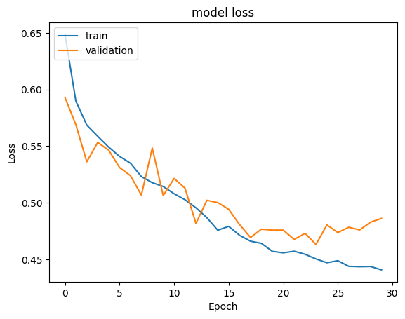

```python
#Plotting Train Loss vs Validation Loss
plt.plot(history5.history['loss'])
plt.plot(history5.history['val_loss'])
plt.title('model loss')
plt.ylabel('Loss')
plt.xlabel('Epoch')
plt.legend(['train', 'validation'], loc='upper left')
plt.show()
```

```python
model5_train_perf = model_performance_classification(model5, x_train_smote, y_train_smote)
model5_train_perf
```

|  | Accuracy | Recall | Precision | F1 Score |
| --- | --- | --- | --- | --- |
| 0 | 0.814 | 0.859 | 0.788 | 0.822 |

```python
model5_valid_perf = model_performance_classification(model5,x_val, y_val)
model5_valid_perf
```

|  | Accuracy | Recall | Precision | F1 Score |
| --- | --- | --- | --- | --- |
| 0 | 0.763 | 0.782 | 0.453 | 0.574 |

```python
#Predicting the results using best as a threshold
y_train_pred = model5.predict(x_train_smote)
y_train_pred = (y_train_pred > 0.5)
#Predicting the results using best as a threshold
y_val_pred = model5.predict(x_val)
y_val_pred = (y_val_pred > 0.5)
```

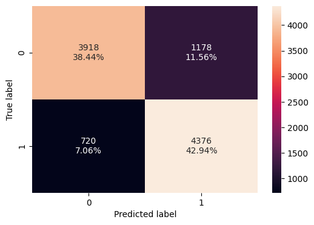

```python
#training set confusion matrix
make_confusion_matrix(y_train_smote, y_train_pred)
```

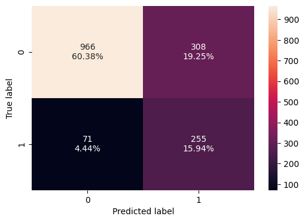

```python
#validation set confusion matrix
make_confusion_matrix(y_val, y_val_pred)
```

## Model Performance Comparison and Final Model Selection

```python
# training performance comparison

models_train_comp_df = pd.concat(
    [
        model0_train_perf.T,
        model1_train_perf.T,
        model2_train_perf.T,
        model3_train_perf.T,
        model4_train_perf.T,
        model5_train_perf.T,
    ],
    axis=1,
)
models_train_comp_df.columns = [
    "Neural Network (SGD, No dropout )",
    "Neural Network (Adam, No dropout )",
    "Neural Network (Adam, dropout [0.4,0.2])",
    "Neural Network (Balanced SGD)",
    "Neural Network (Balanced Adam)",
    "Neural Network (Balanced Adam,dropout [0.4,0.2])"
]
```

```python
#Validation performance comparison

models_valid_comp_df = pd.concat(
    [
        model0_valid_perf.T,
        model1_valid_perf.T,
        model2_valid_perf.T,
        model3_valid_perf.T,
        model4_valid_perf.T,
        model5_valid_perf.T,
    ],
    axis=1,
)
models_valid_comp_df.columns = [
    "Neural Network (SGD, No dropout )",
    "Neural Network (Adam, No dropout )",
    "Neural Network (Adam, dropout [0.4,0.2])",
    "Neural Network (Balanced SGD)",
    "Neural Network (Balanced Adam)",
    "Neural Network (Balanced Adam,dropout [0.4,0.2])"
]
```

```python
# print training performance
models_train_comp_df
```

|  | Neural Network (SGD, No dropout ) | Neural Network (Adam, No dropout ) | Neural Network (Adam, dropout [0.4,0.2]) | Neural Network (Balanced SGD) | Neural Network (Balanced Adam) | Neural Network (Balanced Adam,dropout [0.4,0.2]) |
| --- | --- | --- | --- | --- | --- | --- |
| Accuracy | 0.837 | 0.886 | 0.870 | 0.808 | 0.835 | 0.814 |
| Recall | 0.340 | 0.594 | 0.481 | 0.817 | 0.896 | 0.859 |
| Precision | 0.706 | 0.795 | 0.803 | 0.802 | 0.798 | 0.788 |
| F1 Score | 0.459 | 0.680 | 0.601 | 0.809 | 0.844 | 0.822 |

```python
#print validation performance
models_valid_comp_df
```

|  | Neural Network (SGD, No dropout ) | Neural Network (Adam, No dropout ) | Neural Network (Adam, dropout [0.4,0.2]) | Neural Network (Balanced SGD) | Neural Network (Balanced Adam) | Neural Network (Balanced Adam,dropout [0.4,0.2]) |
| --- | --- | --- | --- | --- | --- | --- |
| Accuracy | 0.832 | 0.850 | 0.858 | 0.762 | 0.758 | 0.763 |
| Recall | 0.307 | 0.479 | 0.417 | 0.706 | 0.748 | 0.782 |
| Precision | 0.699 | 0.690 | 0.782 | 0.447 | 0.444 | 0.453 |
| F1 Score | 0.426 | 0.565 | 0.544 | 0.547 | 0.558 | 0.574 |

```python
#get difference between Recall values of training and validation set
models_train_comp_df.loc["Recall"] - models_valid_comp_df.loc["Recall"]
```

```
Neural Network (SGD, No dropout )                  0.034
Neural Network (Adam, No dropout )                 0.116
Neural Network (Adam, dropout [0.4,0.2])           0.064
Neural Network (Balanced SGD)                      0.111
Neural Network (Balanced Adam)                     0.147
Neural Network (Balanced Adam,dropout [0.4,0.2])   0.077
Name: Recall, dtype: float64
```

- Reasoning:
  - Better Recall score on the training set (~0.86), indicating strong performance in learning from the training data.
  - Best stable Recall score on the validation set (~0.78), demonstrating good performance in generalizing to unseen data.
  - The model is stable with validation set and hence, will deliver better performance with unknown testing set.

## Actionable Insights and Business Recommendations

- The Bank can deploy the final model from this exercise to identify with a reasonable degree of accuracy whether a customer is likely to exite or not, and this process seems to be easier and more time-efficient than other methods.
- The Bank should focus on Germany location. It should find the reason for higher number of exites overall
- The Bank should evaluvate their system with feedbacks from customers. It will list the areas of improvement
- Consier offering Referral bonus along with reducing minimal balance check
- Bank can initiate partnership with global/local vendors to improve credit card usage. This attracts customers to open/maintain the account
- System person can employ techniques like ensemble methods like SMOTE (Synthetic Minority Over-sampling Technique) and use appropriate evaluation metrics like Recall or address class imbalance. Ensuring a balanced dataset is crucial for model training to avoid biased predictions.

Power Ahead